# # Project: Investigate a Dataset (tmdb-movies)

- Introduction
- Data Wrangling
- Exploratory Data Analysis
- Conclusions

## Introduction

In this analysis i am trying to analyse the TMDB Movies and slice data into smaller pieces to get results based on the questions below:

```
1. What is the average popularity for each genre across years?
2. Which genres have the highest revenues in the last decade?
3. What are the most 10 movie names that earned the most?
4. Which 10 directors have more successful movies (rating more than 7) and got high difference between revenue and budget?
5. Is there a relation between vote average and revenue?
```

```python
import pandas as pd
import numpy as np
import matplotlib.pyplot as plt
%matplotlib inline
import seaborn as sns
```

## Data Wrangling

In this section i will be gathering, asessing and cleaning the data to be ready for the analysis process

### General Properties

```python
#Loading the data file
df=pd.read_csv('tmdb-movies.csv')
df.head(1)
```

|  | id | imdb_id | popularity | budget | revenue | original_title | cast | homepage | director | tagline | ... | overview | runtime | genres | production_companies | release_date | vote_count | vote_average | release_year | budget_adj | revenue_adj |
| --- | --- | --- | --- | --- | --- | --- | --- | --- | --- | --- | --- | --- | --- | --- | --- | --- | --- | --- | --- | --- | --- |
| 0 | 135397 | tt0369610 | 32.985763 | 150000000 | 1513528810 | Jurassic World | Chris Pratt\|Bryce Dallas Howard\|Irrfan Khan\|Vi... | http://www.jurassicworld.com/ | Colin Trevorrow | The park is open. | ... | Twenty-two years after the events of Jurassic ... | 124 | Action\|Adventure\|Science Fiction\|Thriller | Universal Studios\|Amblin Entertainment\|Legenda... | 6/9/15 | 5562 | 6.5 | 2015 | 1.379999e+08 | 1.392446e+09 |

1 rows × 21 columns

```python
#Removing the columns that we will not use in our analysis
df.drop(['imdb_id','homepage','overview','release_date','keywords','cast','tagline','production_companies','budget_adj','revenue_adj'],axis=1,inplace=True)
df.head()
```

|  | id | popularity | budget | revenue | original_title | director | runtime | genres | vote_count | vote_average | release_year |
| --- | --- | --- | --- | --- | --- | --- | --- | --- | --- | --- | --- |
| 0 | 135397 | 32.985763 | 150000000 | 1513528810 | Jurassic World | Colin Trevorrow | 124 | Action\|Adventure\|Science Fiction\|Thriller | 5562 | 6.5 | 2015 |
| 1 | 76341 | 28.419936 | 150000000 | 378436354 | Mad Max: Fury Road | George Miller | 120 | Action\|Adventure\|Science Fiction\|Thriller | 6185 | 7.1 | 2015 |
| 2 | 262500 | 13.112507 | 110000000 | 295238201 | Insurgent | Robert Schwentke | 119 | Adventure\|Science Fiction\|Thriller | 2480 | 6.3 | 2015 |
| 3 | 140607 | 11.173104 | 200000000 | 2068178225 | Star Wars: The Force Awakens | J.J. Abrams | 136 | Action\|Adventure\|Science Fiction\|Fantasy | 5292 | 7.5 | 2015 |
| 4 | 168259 | 9.335014 | 190000000 | 1506249360 | Furious 7 | James Wan | 137 | Action\|Crime\|Thriller | 2947 | 7.3 | 2015 |

```python
#Checking the characterstics of the data
df.describe()
```

|  | id | popularity | budget | revenue | runtime | vote_count | vote_average | release_year |
| --- | --- | --- | --- | --- | --- | --- | --- | --- |
| count | 10866.000000 | 10866.000000 | 1.086600e+04 | 1.086600e+04 | 10866.000000 | 10866.000000 | 10866.000000 | 10866.000000 |
| mean | 66064.177434 | 0.646441 | 1.462570e+07 | 3.982332e+07 | 102.070863 | 217.389748 | 5.974922 | 2001.322658 |
| std | 92130.136561 | 1.000185 | 3.091321e+07 | 1.170035e+08 | 31.381405 | 575.619058 | 0.935142 | 12.812941 |
| min | 5.000000 | 0.000065 | 0.000000e+00 | 0.000000e+00 | 0.000000 | 10.000000 | 1.500000 | 1960.000000 |
| 25% | 10596.250000 | 0.207583 | 0.000000e+00 | 0.000000e+00 | 90.000000 | 17.000000 | 5.400000 | 1995.000000 |
| 50% | 20669.000000 | 0.383856 | 0.000000e+00 | 0.000000e+00 | 99.000000 | 38.000000 | 6.000000 | 2006.000000 |
| 75% | 75610.000000 | 0.713817 | 1.500000e+07 | 2.400000e+07 | 111.000000 | 145.750000 | 6.600000 | 2011.000000 |
| max | 417859.000000 | 32.985763 | 4.250000e+08 | 2.781506e+09 | 900.000000 | 9767.000000 | 9.200000 | 2015.000000 |

```python
#checking if there are missing values
df.info()
```

```
<class 'pandas.core.frame.DataFrame'>
RangeIndex: 10866 entries, 0 to 10865
Data columns (total 11 columns):
id                10866 non-null int64
popularity        10866 non-null float64
budget            10866 non-null int64
revenue           10866 non-null int64
original_title    10866 non-null object
director          10822 non-null object
runtime           10866 non-null int64
genres            10843 non-null object
vote_count        10866 non-null int64
vote_average      10866 non-null float64
release_year      10866 non-null int64
dtypes: float64(2), int64(6), object(3)
memory usage: 933.9+ KB
```

```python
#checking if we have duplicated rows
sum(df.duplicated())
```

```
1
```

### Data Cleaning (removing duplicates,dealing with missing values)

```python
#Removing the duplicated rows
df=df.drop_duplicates()
#Checking that duplicated rows were deleted
sum(df.duplicated())
```

```
0
```

**Dealing with missing values**

As we have missing values in the direcor and genres_list and those are not numeric data so we are going to drop them

```python
df.dropna(inplace=True)
```

## Exploratory Data Analysis

### Research Question 1 (What is the average popularity for each genre across years?)

```python
#turning the genres column values into a dataframe
genres_list=df['genres'].str.split('|',expand=True)[0]
genres_list=genres_list
genres_list=pd.DataFrame(genres_list)
genres_list.head()
```

|  | 0 |
| --- | --- |
| 0 | Action |
| 1 | Action |
| 2 | Adventure |
| 3 | Action |
| 4 | Action |

```python
#Renaming the column name
genres_list.rename(columns={0:'main_genre'},inplace=True)
```

```python
#Merging genres_list with tmdb movies
Merged_df=pd.merge(df,genres_list,left_index=True,right_index=True)
Merged_df.head(1)
```

|  | id | popularity | budget | revenue | original_title | director | runtime | genres | vote_count | vote_average | release_year | main_genre |
| --- | --- | --- | --- | --- | --- | --- | --- | --- | --- | --- | --- | --- |
| 0 | 135397 | 32.985763 | 150000000 | 1513528810 | Jurassic World | Colin Trevorrow | 124 | Action\|Adventure\|Science Fiction\|Thriller | 5562 | 6.5 | 2015 | Action |

```python
#Creating a data frame for each genre with years and the population mean
gen=list(Merged_df['main_genre'].unique())
gen=['Action','Adventure','Western','Science Fiction','Drama','Family','Comedy','Crime','Romance','War','Mystery','Thriller','Fantasy','History','Animation','Horror','Music','Documentary','TV Movie','Foreign']
new_df=Merged_df.groupby(['release_year','main_genre'],as_index=False).popularity.mean()
pd.DataFrame(new_df)
action=new_df[new_df['main_genre']==gen[0]]
adventure=new_df[new_df['main_genre']==gen[1]]
western=new_df[new_df['main_genre']==gen[2]]
science_fiction=new_df[new_df['main_genre']==gen[3]]
drama=new_df[new_df['main_genre']==gen[4]]
family=new_df[new_df['main_genre']==gen[5]]
comedy=new_df[new_df['main_genre']==gen[6]]
crime=new_df[new_df['main_genre']==gen[7]]
romance=new_df[new_df['main_genre']==gen[8]]
war=new_df[new_df['main_genre']==gen[9]]
mystery=new_df[new_df['main_genre']==gen[10]]
thriller=new_df[new_df['main_genre']==gen[11]]
fantasy=new_df[new_df['main_genre']==gen[12]]
history=new_df[new_df['main_genre']==gen[13]]
animation=new_df[new_df['main_genre']==gen[14]]
horror=new_df[new_df['main_genre']==gen[15]]
music=new_df[new_df['main_genre']==gen[16]]
documentary=new_df[new_df['main_genre']==gen[17]]
tv_movie=new_df[new_df['main_genre']==gen[18]]
foreign=new_df[new_df['main_genre']==gen[19]]
```

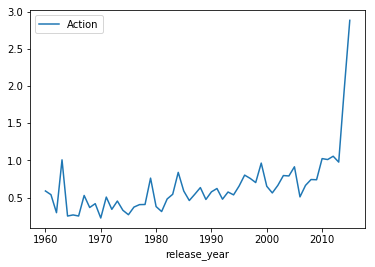

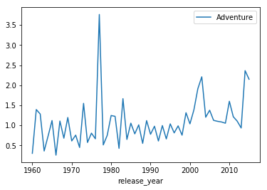

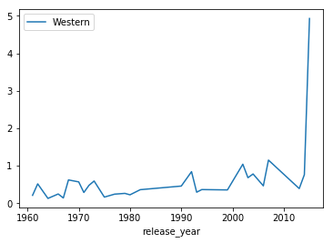

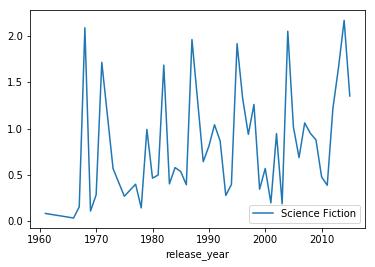

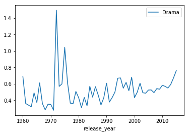

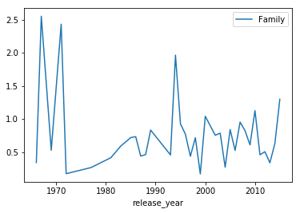

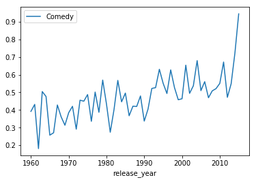

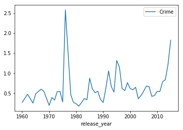

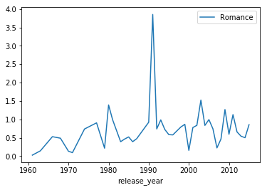

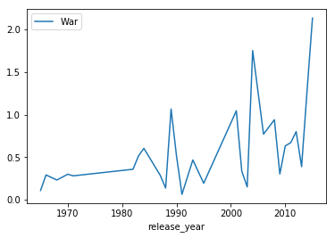

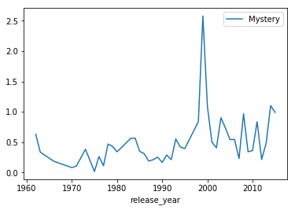

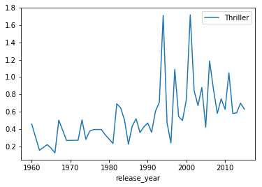

[8 more figures not shown]

```python
#Making line chart for earch genre to show its popularity over years
action.plot(x='release_year',y='popularity',kind='line',label='Action')
adventure.plot(x='release_year',y='popularity',kind='line',label='Adventure')
western.plot(x='release_year',y='popularity',kind='line',label='Western')
science_fiction.plot(x='release_year',y='popularity',kind='line',label='Science Fiction')
drama.plot(x='release_year',y='popularity',kind='line',label='Drama')
family.plot(x='release_year',y='popularity',kind='line',label='Family')
comedy.plot(x='release_year',y='popularity',kind='line',label='Comedy')
crime.plot(x='release_year',y='popularity',kind='line',label='Crime')
romance.plot(x='release_year',y='popularity',kind='line',label='Romance')
war.plot(x='release_year',y='popularity',kind='line',label='War')
mystery.plot(x='release_year',y='popularity',kind='line',label='Mystery')
thriller.plot(x='release_year',y='popularity',kind='line',label='Thriller')
fantasy.plot(x='release_year',y='popularity',kind='line',label='Fantasy')
history.plot(x='release_year',y='popularity',kind='line',label='History')
animation.plot(x='release_year',y='popularity',kind='line',label='Animation')
horror.plot(x='release_year',y='popularity',kind='line',label='Horror')
music.plot(x='release_year',y='popularity',kind='line',label='Music')
documentary.plot(x='release_year',y='popularity',kind='line',label='Documentary')
tv_movie.plot(x='release_year',y='popularity',kind='line',label='TV_movie')
foreign.plot(x='release_year',y='popularity',kind='line',label='Foreign');
```

**The line chart above may give us an impact of how the popularity for a genre may change over years**

### Research Question 2 (Which genres have the highest revenues in the last decade?)

```python
#Creating a function to filter the data without the zero values for budget & revenue and getting the mean revenue for each genre
def filtered_data(dataframe):
    non_zero=Merged_df[(Merged_df.revenue>0)&(Merged_df.budget>0)]
    after_2010=non_zero[non_zero.release_year>2010]
    Mean=after_2010.groupby('main_genre').revenue.mean()
    return Mean
filtered_data(Merged_df)
```

```
main_genre
Action             2.567572e+08
Adventure          3.137198e+08
Animation          3.385821e+08
Comedy             8.674498e+07
Crime              8.096155e+07
Documentary        3.301381e+07
Drama              5.326479e+07
Family             2.546000e+08
Fantasy            2.313605e+08
History            6.809011e+07
Horror             5.831896e+07
Music              7.379552e+07
Mystery            6.688709e+07
Romance            1.135280e+08
Science Fiction    3.281577e+08
Thriller           6.856998e+07
War                2.110133e+08
Western            1.784622e+08
Name: revenue, dtype: float64
```

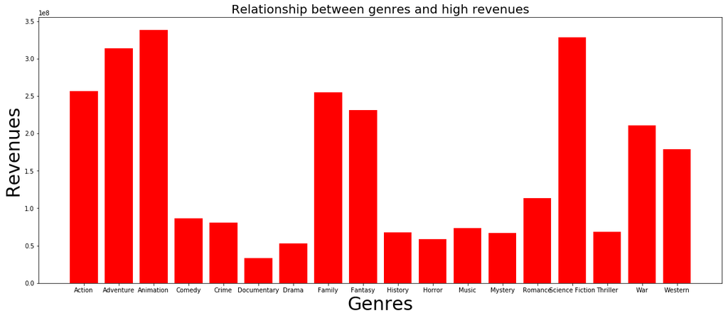

```python
#Making a bar plot for the relation between high revenues and genre in the last decade
plt.subplots(figsize=(20,8))
plt.bar(Mean.index,Mean,color='r')
plt.title('Relationship between genres and high revenues',fontsize=20)
plt.xlabel('Genres',fontsize=30)
plt.ylabel('Revenues',fontsize=30);
```

### Research Question 3 (What are the most 10 movie names that earned the most?)

```python
#getting the difference between budget and revenue and add the difference column to non_zero dataframe
non_zero['difference']=non_zero['revenue']-non_zero['budget']
top_ten=non_zero.sort_values('difference').tail(10)
top_ten
```

|  | id | popularity | budget | revenue | original_title | director | runtime | genres | vote_count | vote_average | release_year | main_genre | difference |
| --- | --- | --- | --- | --- | --- | --- | --- | --- | --- | --- | --- | --- | --- |
| 8094 | 1642 | 1.136610 | 22000000 | 1106279658 | The Net | Irwin Winkler | 114 | Crime\|Drama\|Mystery\|Thriller\|Action | 201 | 5.6 | 1995 | Crime | 1084279658 |
| 5422 | 109445 | 6.112766 | 150000000 | 1274219009 | Frozen | Chris Buck\|Jennifer Lee | 102 | Animation\|Adventure\|Family | 3369 | 7.5 | 2013 | Animation | 1124219009 |
| 14 | 99861 | 5.944927 | 280000000 | 1405035767 | Avengers: Age of Ultron | Joss Whedon | 141 | Action\|Adventure\|Science Fiction | 4304 | 7.4 | 2015 | Action | 1125035767 |
| 3374 | 12445 | 5.711315 | 125000000 | 1327817822 | Harry Potter and the Deathly Hallows: Part 2 | David Yates | 130 | Adventure\|Family\|Fantasy | 3750 | 7.7 | 2011 | Adventure | 1202817822 |
| 4361 | 24428 | 7.637767 | 220000000 | 1519557910 | The Avengers | Joss Whedon | 143 | Science Fiction\|Action\|Adventure | 8903 | 7.3 | 2012 | Science Fiction | 1299557910 |
| 4 | 168259 | 9.335014 | 190000000 | 1506249360 | Furious 7 | James Wan | 137 | Action\|Crime\|Thriller | 2947 | 7.3 | 2015 | Action | 1316249360 |
| 0 | 135397 | 32.985763 | 150000000 | 1513528810 | Jurassic World | Colin Trevorrow | 124 | Action\|Adventure\|Science Fiction\|Thriller | 5562 | 6.5 | 2015 | Action | 1363528810 |
| 5231 | 597 | 4.355219 | 200000000 | 1845034188 | Titanic | James Cameron | 194 | Drama\|Romance\|Thriller | 4654 | 7.3 | 1997 | Drama | 1645034188 |
| 3 | 140607 | 11.173104 | 200000000 | 2068178225 | Star Wars: The Force Awakens | J.J. Abrams | 136 | Action\|Adventure\|Science Fiction\|Fantasy | 5292 | 7.5 | 2015 | Action | 1868178225 |
| 1386 | 19995 | 9.432768 | 237000000 | 2781505847 | Avatar | James Cameron | 162 | Action\|Adventure\|Fantasy\|Science Fiction | 8458 | 7.1 | 2009 | Action | 2544505847 |

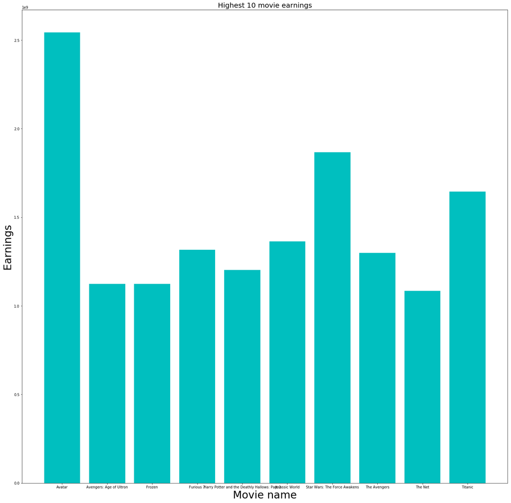

```python
#creating a bar chart showing the highest 10 movie earnings
plt.subplots(figsize=(25,25))
plt.bar(top_ten['original_title'][0:],top_ten['difference'][0:],color='c')
plt.title('Highest 10 movie earnings',fontsize=20)
plt.xlabel('Movie name',fontsize=30)
plt.ylabel('Earnings',fontsize=30);
plt.legend()
```

### The chart above showing the top ten movies which have made the best difference between revenues and budget

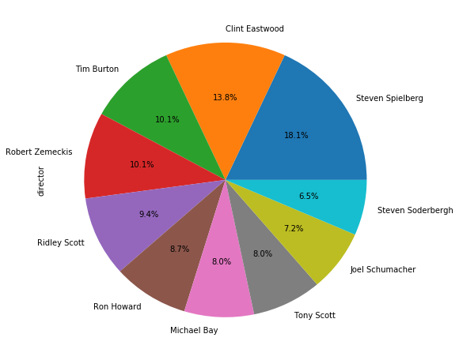

```python
#Getting the most 10 directors who got high ratings from the audience and also achieved high profits
#profits was measured by the median of the total differences
high_average=non_zero.query('vote_average>=7'and 'difference>difference.median()')
high_average['director'].value_counts()[:10].plot(kind='pie',figsize=(8,8),autopct='%1.1f%%');
```

### Research Question 5 (Is there a relation between vote average and revenue?)

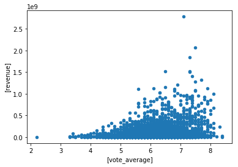

```python
#Creating a scatter plot to show the relation between vote average and revenue
non_zero.plot(x=['vote_average'],y=['revenue'],kind='scatter');
```

**As shown there is a positive correlation but there are some exceptions due to another properties, so in general when a movie got higher rating,it gor higher revenue but it differs according to the releasing year or movie genre or as in Avatar as it was a brandnew movie in that time.**

## Conclusions

#### First of all , i wanted to show how the popularity of a genre would change over the years and i visualized this using a line chart for each genre showing the average population over the years.

**Then,I sliced the data to get the top 10 movies that achieved the highest difference between movie budget and revenue and visualized it using a bar chart**

**Finally,I analyzed the data to get the correlation between vote average and high revenues, does every good movie get high revenue?** **Well, there was a positive correlation but it is not a matter we would assume as the highest movie in my analysis was Avatar and by far,and from my scatter visualization we can see that there are some exceptions.**

**We can also notice that after rating average with 8,the scatter was somehow down,so yes in general there is a positive correlation but this is not the only factor.**

## Limitations

**The data was missing too many values in budget and revenue so i had to filter it to get practical results,this could impact the data negatively.**

**Having a column for critic reviews would have been very useful when comparing it with the average rating, but unfortunately that was not included**

**There is no currency mentioned in the dataset so the budget and revenue were in numerical values**

```python
from subprocess import call
call(['python', '-m', 'nbconvert', 'Investigate_a_Dataset.ipynb'])
```

```
0
```